# AR in Journalism

Understanding the effect of Augmented Reality (AR) in Journalism.

Three reading modalities were defined:

- Augmented Reality (AR)
- Interactive visualizations (INTERACTIVE)
- Static visualizations (STATIC)

Three pieces of information were defined:

- Chemical bomb attack in Syria (Syria)
- Youth soccer team reascue operation in Thailand (Thai)
- Olympici skate figure Nathan Chen (Olympic)

## Sense of Presence

Studying the effect of the modality and piece of information in the subjects’ sense of presence.

```r
i_cols = c('SUBJECT','CONDITION','PRESENCE_TOTAL_OLYM', 'PRESENCE_TOTAL_SYRIA',
           'PRESENCE_TOTAL_THAI')
p_data = prepare_data(df_c, i_cols)
```

```
## [1] "Subjects removed because of missing values: 0"
```

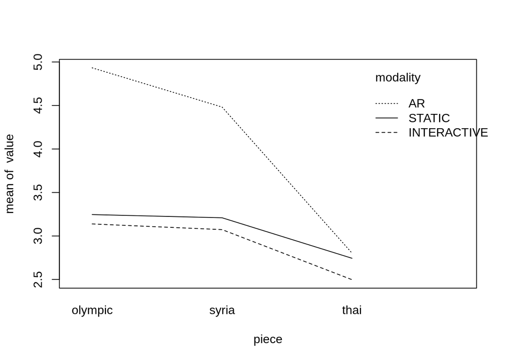

### Analysis of Variance

```r
# Define model
m = art(value ~ modality * piece + (1|subject), data=p_data)
anova(m)
```

```
## Analysis of Variance of Aligned Rank Transformed Data
##
## Table Type: Analysis of Deviance Table (Type III Wald F tests with Kenward-Roger df)
## Model: Mixed Effects (lmer)
## Response: art(value)
##
##                        F Df Df.res     Pr(>F)
## 1 modality       12.1242  2     76 2.6914e-05 ***
## 2 piece          27.4805  2    152 6.4951e-11 ***
## 3 modality:piece  4.5437  4    152  0.0017058  **
## ---
## Signif. codes:   0 '***' 0.001 '**' 0.01 '*' 0.05 '.' 0.1 ' ' 1
```

*The sense of presence is significalty affected by the reading modality, the piece of information, and the interaction between them.*

### Post-Hoc on Modality

```r
# Pairwise comparisons using Holm-Bonferroni correction
do_post_hoc_modalities(p_data)
```

```
## Significant difference found between: AR and INTERACTIVE
## --- Method=Wilcoxon rank sum test with continuity correction
## --- W=4885
## --- p-value=1.12634975047643e-06
##
## Significant difference found between: AR and STATIC
## --- Method=Wilcoxon rank sum test with continuity correction
## --- W=4367
## --- p-value=1.93966510543491e-05
```

### Post-Hoc on Piece

```r
# Pairwise comparisons using Holm-Bonferroni correction
do_post_hoc_pieces(p_data)
```

```
## Significant difference found between: thai and syria
## --- Method=Wilcoxon rank sum test with continuity correction
## --- W=1936.5
## --- p-value=3.85952259677764e-05
##
## Significant difference found between: thai and olympic
## --- Method=Wilcoxon rank sum test with continuity correction
## --- W=1689
## --- p-value=6.46566723875198e-07
```

### Post-Hoc on Interaction

```r
# Pairwise comparisons using Holm-Bonferroni correction
do_post_hoc_modalities_pieces(p_data)
```

```
## Significant difference found between: AR and INTERACTIVE on piece syria
## --- Method=Wilcoxon rank sum test with continuity correction
## --- W=588
## --- p-value=0.000387118847663516
##
## Significant difference found between: AR and INTERACTIVE on piece olympic
## --- Method=Wilcoxon rank sum test with continuity correction
## --- W=652
## --- p-value=3.69677671397045e-06
##
## Significant difference found between: AR and STATIC on piece syria
## --- Method=Wilcoxon rank sum test with continuity correction
## --- W=528
## --- p-value=0.00133908961724457
##
## Significant difference found between: AR and STATIC on piece olympic
## --- Method=Wilcoxon rank sum test
## --- W=609
## --- p-value=5.92362804459267e-07
```

*The post hoc analysis shows that there is a significant difference in the sense of presence between AR and Interactive and AR and Static on the syria and olympic pieces*

## Narrative Engagement and Transportation

Studying the effect of the modality and piece of information in the subjects’ narrative engagement and transportation.

```r
i_cols = c('SUBJECT','CONDITION','ENGAGE_TOTAL_OLYM', 'ENGAGE_TOTAL_SYRIA',
           'ENGAGE_TOTAL_THAI')
p_data = prepare_data(df_c, i_cols)
```

```
## [1] "Subjects removed because of missing values: 0"
```

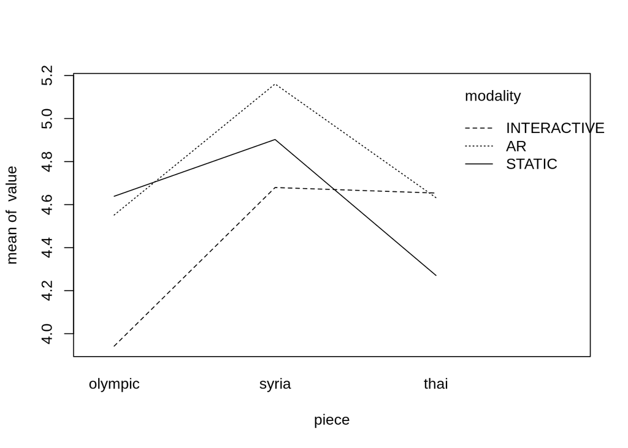

### Analysis of Variance

```r
# Define model
m = art(value ~ modality * piece + (1|subject), data=p_data)
anova(m)
```

```
## Analysis of Variance of Aligned Rank Transformed Data
##
## Table Type: Analysis of Deviance Table (Type III Wald F tests with Kenward-Roger df)
## Model: Mixed Effects (lmer)
## Response: art(value)
##
##                        F Df Df.res    Pr(>F)
## 1 modality        1.7427  2     76  0.181974
## 2 piece          11.9931  2    152 1.458e-05 ***
## 3 modality:piece  3.1694  4    152  0.015546   *
## ---
## Signif. codes:   0 '***' 0.001 '**' 0.01 '*' 0.05 '.' 0.1 ' ' 1
```

*The piece of information affects significantly the narrative engagement and transportation. Additionally, the interaction between modality and piece of information appears to signficanly influence engagement and transportation also.*

### Post-Hoc on Piece

```r
# Pairwise comparisons using Holm-Bonferroni correction
do_post_hoc_pieces(p_data)
```

```
## Significant difference found between: thai and syria
## --- Method=Wilcoxon rank sum test with continuity correction
## --- W=2284.5
## --- p-value=0.00358046297411687
##
## Significant difference found between: syria and olympic
## --- Method=Wilcoxon rank sum test with continuity correction
## --- W=4260.5
## --- p-value=7.14749808205805e-05
```

### Post-Hoc on Interaction

```r
# Pairwise comparisons using Holm-Bonferroni correction
do_post_hoc_modalities_pieces(p_data)
```

```
## Significant difference found between: AR and INTERACTIVE on piece olympic
## --- Method=Wilcoxon rank sum test with continuity correction
## --- W=497.5
## --- p-value=0.04258646809127
##
## Significant difference found between: INTERACTIVE and STATIC on piece olympic
## --- Method=Wilcoxon rank sum test with continuity correction
## --- W=191.5
## --- p-value=0.0193567629322578
```

*There is a significant difference in the engagement and transportation between AR and Interactive on the Olympic piece. A similar result is found between Interactive and Static.*

## Perceived Learning

Studying the effect of the modality and piece of information in the subjects’ perceived learning.

```r
i_cols = c('SUBJECT','CONDITION', 'PERCEIV_LEARN_VISU_TOTAL_OLYM',
           'PERCEIV_LEARN_VISU_TOTAL_SYRIA', 'PERCEIV_LEARN_VISU_TOTAL_THAI')
p_data = prepare_data(df_c, i_cols)
```

```
## [1] "Subjects removed because of missing values: 2"
```

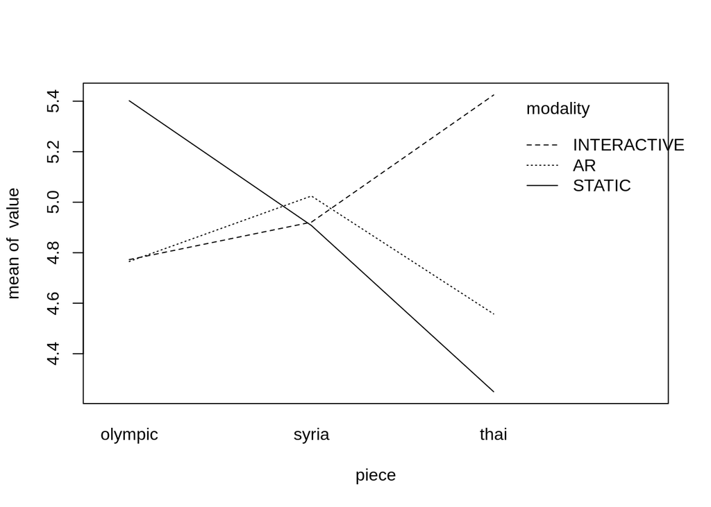

### Analysis of Variance

```r
# Define model
m = art(value ~ modality * piece + (1|subject), data=p_data)
anova(m)
```

```
## Analysis of Variance of Aligned Rank Transformed Data
##
## Table Type: Analysis of Deviance Table (Type III Wald F tests with Kenward-Roger df)
## Model: Mixed Effects (lmer)
## Response: art(value)
##
##                        F Df Df.res     Pr(>F)
## 1 modality       0.82196  2     74 0.44354172
## 2 piece          0.42585  2    148 0.65401537
## 3 modality:piece 5.28908  4    148 0.00052117 ***
## ---
## Signif. codes:   0 '***' 0.001 '**' 0.01 '*' 0.05 '.' 0.1 ' ' 1
```

*What influence the perceived learning is the interaction between reading modality and piece of information.*

### Post-Hoc on Interaction

```r
# Pairwise comparisons using Holm-Bonferroni correction
do_post_hoc_modalities_pieces(p_data)
```

```
## Significant difference found between: AR and INTERACTIVE on piece thai
## --- Method=Wilcoxon rank sum test with continuity correction
## --- W=215.5
## --- p-value=0.0104010423672734
##
## Significant difference found between: INTERACTIVE and STATIC on piece thai
## --- Method=Wilcoxon rank sum test
## --- W=412
## --- p-value=0.0232536215900561
##
## Significant difference found between: INTERACTIVE and STATIC on piece olympic
## --- Method=Wilcoxon rank sum test with continuity correction
## --- W=189
## --- p-value=0.0282558966414549
```

*There is significant difference in the perceived learning between AR and Interactive on the Thai piece.*

## Perceived Learning (II)

```r
i_cols = c('SUBJECT','CONDITION', 'PerceiveLearnGeneral_O',
           'PerceiveLearnGeneral_T', 'PerceiveLearnGeneral_S')
p_data = prepare_data(df_c, i_cols)
```

```
## [1] "Subjects removed because of missing values: 0"
```

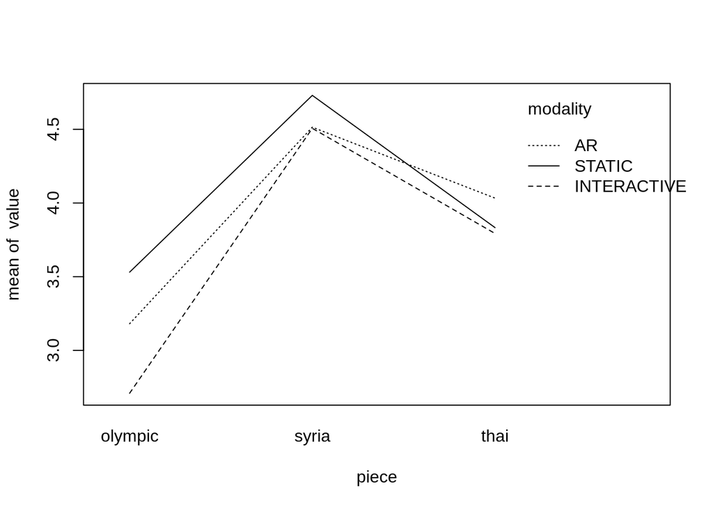

### Analysis of Variance

```r
# Define model
m = art(value ~ modality * piece + (1|subject), data=p_data)
anova(m)
```

```
## Analysis of Variance of Aligned Rank Transformed Data
##
## Table Type: Analysis of Deviance Table (Type III Wald F tests with Kenward-Roger df)
## Model: Mixed Effects (lmer)
## Response: art(value)
##
##                         F Df Df.res     Pr(>F)
## 1 modality        0.44030  2     76    0.64548
## 2 piece          21.31829  2    152 6.9032e-09 ***
## 3 modality:piece  0.66032  4    152    0.62051
## ---
## Signif. codes:   0 '***' 0.001 '**' 0.01 '*' 0.05 '.' 0.1 ' ' 1
```

### Post-Hoc on Piece

```r
# Pairwise comparisons using Holm-Bonferroni correction
do_post_hoc_pieces(p_data)
```

```
## Significant difference found between: thai and syria
## --- Method=Wilcoxon rank sum test with continuity correction
## --- W=2267
## --- p-value=0.00300688682233806
##
## Significant difference found between: thai and olympic
## --- Method=Wilcoxon rank sum test with continuity correction
## --- W=3966
## --- p-value=0.00327856085494686
##
## Significant difference found between: syria and olympic
## --- Method=Wilcoxon rank sum test with continuity correction
## --- W=4608.5
## --- p-value=2.26621063916772e-07
```

## Objective knowledge gain (I)

```r
i_cols = c('SUBJECT','CONDITION', 'OBJECT_LEARN_DESC_O',
           'OBJECT_LEARN_DESC_ALL_S', 'OBJECT_LEARN_DESC_TOT_T')
p_data = prepare_data(df_c, i_cols)
```

```
## [1] "Subjects removed because of missing values: 0"
```

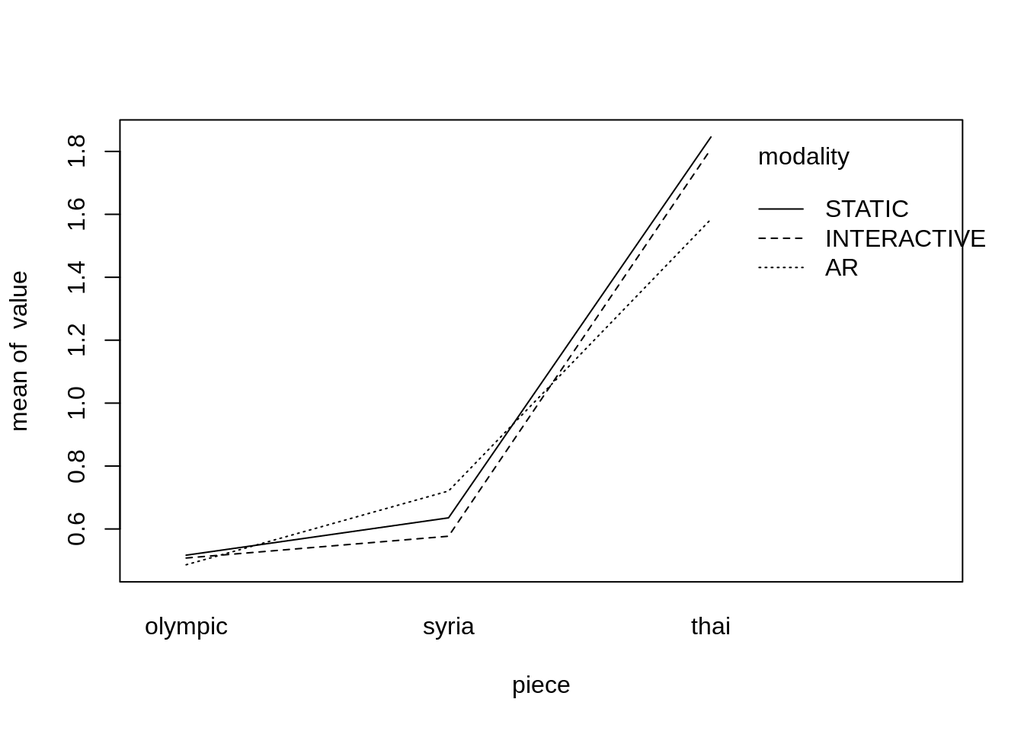

### Analysis of Variance

```r
# Define model
m = art(value ~ modality * piece + (1|subject), data=p_data)
anova(m)
```

```
## Analysis of Variance of Aligned Rank Transformed Data
##
## Table Type: Analysis of Deviance Table (Type III Wald F tests with Kenward-Roger df)
## Model: Mixed Effects (lmer)
## Response: art(value)
##
##                          F Df Df.res   Pr(>F)
## 1 modality         0.34551  2     76 0.708963
## 2 piece          190.79476  2    152  < 2e-16 ***
## 3 modality:piece   2.93465  4    152 0.022599   *
## ---
## Signif. codes:   0 '***' 0.001 '**' 0.01 '*' 0.05 '.' 0.1 ' ' 1
```

*The piece of information influences significantly the objective knowledge gain. The interaction between modality and piece of information show to have a significant effect as well.*

### Post-Hoc on Piece

```r
# Pairwise comparisons using Holm-Bonferroni correction
do_post_hoc_pieces(p_data)
```

```
## Significant difference found between: thai and syria
## --- Method=Wilcoxon rank sum test with continuity correction
## --- W=5755
## --- p-value=4.77345690947879e-20
##
## Significant difference found between: thai and olympic
## --- Method=Wilcoxon rank sum test with continuity correction
## --- W=5902
## --- p-value=3.53384881485937e-22
##
## Significant difference found between: syria and olympic
## --- Method=Wilcoxon rank sum test with continuity correction
## --- W=3955.5
## --- p-value=0.00359777894853901
```

### Post-Hoc on Interaction

```r
# Pairwise comparisons using Holm-Bonferroni correction
do_post_hoc_modalities_pieces(p_data)
```

```
## Significant difference found between: AR and INTERACTIVE on piece syria
## --- Method=Wilcoxon rank sum test with continuity correction
## --- W=509
## --- p-value=0.025585247700061
```

*There is significant difference in the perceived learning between AR and Interactive on the Syria piece.*

## Objective knowledge gain (II)

```r
i_cols = c('SUBJECT','CONDITION', 'OBJECT_LEARN_SPEC_ALL_O',
           'OBJECTLEARN_SPEC_ALL_S', 'OBJECT_LEARN_SPEC_TOT_T')
p_data = prepare_data(df_c, i_cols)
```

```
## [1] "Subjects removed because of missing values: 0"
```

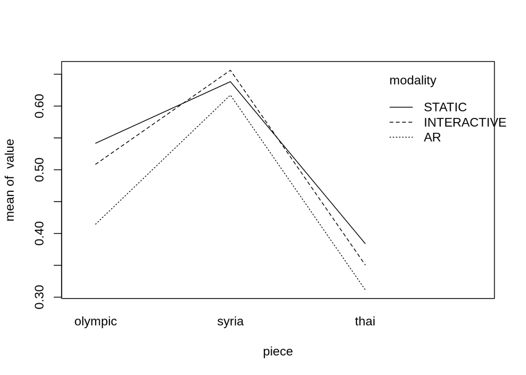

### Analysis of Variance

```r
# Define model
m = art(value ~ modality * piece + (1|subject), data=p_data)
anova(m)
```

```
## Analysis of Variance of Aligned Rank Transformed Data
##
## Table Type: Analysis of Deviance Table (Type III Wald F tests with Kenward-Roger df)
## Model: Mixed Effects (lmer)
## Response: art(value)
##
##                         F Df Df.res  Pr(>F)
## 1 modality        1.64144  2     76 0.20049
## 2 piece          53.30545  2    152 < 2e-16 ***
## 3 modality:piece  0.62924  4    152 0.64236
## ---
## Signif. codes:   0 '***' 0.001 '**' 0.01 '*' 0.05 '.' 0.1 ' ' 1
```

*The piece of information affects significantly the objective knowledge gain.*

### Post-Hoc on Piece

```r
# Pairwise comparisons using Holm-Bonferroni correction
do_post_hoc_pieces(p_data)
```

```
## Significant difference found between: thai and syria
## --- Method=Wilcoxon rank sum test with continuity correction
## --- W=977.5
## --- p-value=8.88026054301622e-14
##
## Significant difference found between: thai and olympic
## --- Method=Wilcoxon rank sum test with continuity correction
## --- W=2010
## --- p-value=0.000111463620986391
##
## Significant difference found between: syria and olympic
## --- Method=Wilcoxon rank sum test with continuity correction
## --- W=4241.5
## --- p-value=9.60992693502203e-05
```

## Perceived Realism and Authenticity

```r
i_cols = c('SUBJECT','CONDITION', 'JOURNAL_TOTAL_OLYM', 'JOURNAL_TOTAL_SYRIA',
           'JOURNAL_TOTAL_THAI')
p_data = prepare_data(df_c, i_cols)
```

```
## [1] "Subjects removed because of missing values: 1"
```

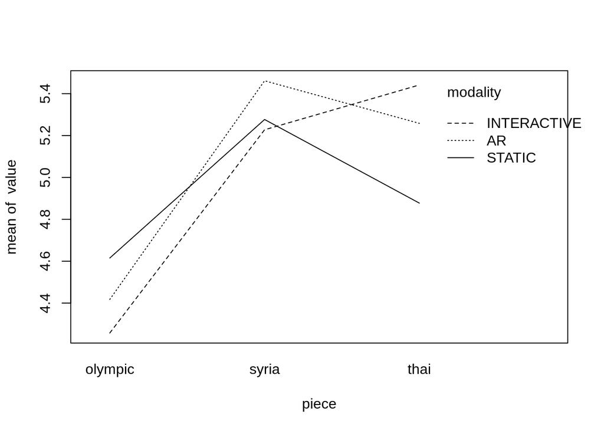

### Analysis of Variance

```r
# Define model
m = art(value ~ modality * piece + (1|subject), data=p_data)
anova(m)
```

```
## Analysis of Variance of Aligned Rank Transformed Data
##
## Table Type: Analysis of Deviance Table (Type III Wald F tests with Kenward-Roger df)
## Model: Mixed Effects (lmer)
## Response: art(value)
##
##                          F Df Df.res   Pr(>F)
## 1 modality        0.041569  2     75 0.959306
## 2 piece          43.104864  2    150 1.62e-15 ***
## 3 modality:piece  1.992045  4    150 0.098591   .
## ---
## Signif. codes:   0 '***' 0.001 '**' 0.01 '*' 0.05 '.' 0.1 ' ' 1
```

*The piece of information affects significantly the perceived of realism and authenticity.*

### Post-Hoc on Piece

```r
# Pairwise comparisons using Holm-Bonferroni correction
do_post_hoc_pieces(p_data)
```

```
## Significant difference found between: thai and olympic
## --- Method=Wilcoxon rank sum test with continuity correction
## --- W=4555.5
## --- p-value=8.19741815650974e-08
##
## Significant difference found between: syria and olympic
## --- Method=Wilcoxon rank sum test with continuity correction
## --- W=4786
## --- p-value=6.42092327584223e-10
```

## Journalistic Norms

```r
i_cols = c('SUBJECT','CONDITION', 'AUTENTICITY_TOTAL_OLYM',
           'AUTENTICITY_TOTAL_SYRIA', 'AUTENTICITY_TOTAL_THAI')
p_data = prepare_data(df_c, i_cols)
```

```
## [1] "Subjects removed because of missing values: 1"
```

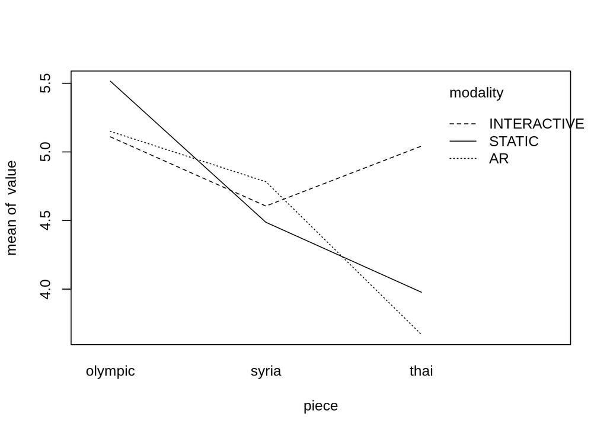

### Analysis of Variance

```r
# Define model
m = art(value ~ modality * piece + (1|subject), data=p_data)
anova(m)
```

```
## Analysis of Variance of Aligned Rank Transformed Data
##
## Table Type: Analysis of Deviance Table (Type III Wald F tests with Kenward-Roger df)
## Model: Mixed Effects (lmer)
## Response: art(value)
##
##                        F Df Df.res     Pr(>F)
## 1 modality        2.2151  2     75 0.11623554
## 2 piece          16.0808  2    150 4.7051e-07 ***
## 3 modality:piece  5.0541  4    150 0.00075457 ***
## ---
## Signif. codes:   0 '***' 0.001 '**' 0.01 '*' 0.05 '.' 0.1 ' ' 1
```

*The pieces of information and their interactions with the reading modality influece significantly the journalism norms.*

### Post-Hoc on Piece

```r
# Pairwise comparisons using Holm-Bonferroni correction
do_post_hoc_pieces(p_data)
```

```
## Significant difference found between: thai and olympic
## --- Method=Wilcoxon rank sum test with continuity correction
## --- W=1869.5
## --- p-value=3.26594497732633e-05
##
## Significant difference found between: syria and olympic
## --- Method=Wilcoxon rank sum test with continuity correction
## --- W=2257
## --- p-value=0.00542549410185415
```

### Post-Hoc on Interaction

```r
# Pairwise comparisons using Holm-Bonferroni correction
do_post_hoc_modalities_pieces(p_data)
```

```
## Significant difference found between: AR and INTERACTIVE on piece thai
## --- Method=Wilcoxon rank sum test
## --- W=154
## --- p-value=0.000101806597153562
##
## Significant difference found between: INTERACTIVE and STATIC on piece thai
## --- Method=Wilcoxon rank sum test with continuity correction
## --- W=398.5
## --- p-value=0.0473217101893847
```

*There is a significant difference in the perceived learning between AR and Interactive on the Thai piece. Similarly, the difference between Interactive and Static is significant on the Thai piece.*

## Relevance

```r
i_cols = c('SUBJECT','CONDITION', 'Rel_O', 'Rel_S', 'Rel_T')
p_data = prepare_data(df_c, i_cols)
```

```
## [1] "Subjects removed because of missing values: 0"
```

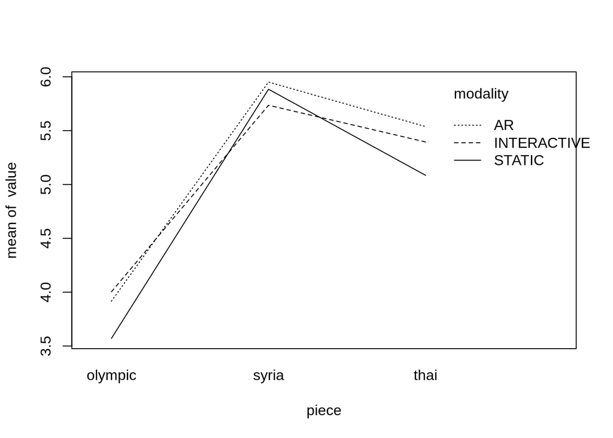

### Analysis of Variance

```r
# Define model
m = art(value ~ modality * piece + (1|subject), data=p_data)
anova(m)
```

```
## Analysis of Variance of Aligned Rank Transformed Data
##
## Table Type: Analysis of Deviance Table (Type III Wald F tests with Kenward-Roger df)
## Model: Mixed Effects (lmer)
## Response: art(value)
##
##                         F Df Df.res  Pr(>F)
## 1 modality         1.0194  2     76 0.36569
## 2 piece          105.9481  2    152 < 2e-16 ***
## 3 modality:piece   1.1692  4    152 0.32666
## ---
## Signif. codes:   0 '***' 0.001 '**' 0.01 '*' 0.05 '.' 0.1 ' ' 1
```

*The pieces of information influece significantly in relevance.*

### Post-Hoc on Piece

```r
# Pairwise comparisons using Holm-Bonferroni correction
do_post_hoc_pieces(p_data)
```

```
## Significant difference found between: thai and syria
## --- Method=Wilcoxon rank sum test with continuity correction
## --- W=2227.5
## --- p-value=0.00190522602481981
##
## Significant difference found between: thai and olympic
## --- Method=Wilcoxon rank sum test with continuity correction
## --- W=5137
## --- p-value=2.36937313797481e-12
##
## Significant difference found between: syria and olympic
## --- Method=Wilcoxon rank sum test with continuity correction
## --- W=5631.5
## --- p-value=2.51977753110365e-18
```

### Post-Hoc on Interaction

```r
# Pairwise comparisons using Holm-Bonferroni correction
do_post_hoc_modalities_pieces(p_data)
```

```
## Significant difference found between: AR and STATIC on piece thai
## --- Method=Wilcoxon rank sum test with continuity correction
## --- W=462.5
## --- p-value=0.0416075145112325
```

*There is a significant difference in relevance between AR and Static on the Thai piece.*

## Accuracy

```r
i_cols = c('SUBJECT','CONDITION', 'Acc_O', 'Acc_S', 'Acc_T')
p_data = prepare_data(df_c, i_cols)
```

```
## [1] "Subjects removed because of missing values: 1"
```

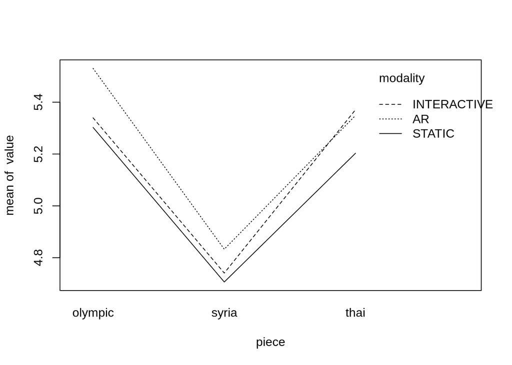

### Analysis of Variance

```r
# Define model
m = art(value ~ modality * piece + (1|subject), data=p_data)
anova(m)
```

```
## Analysis of Variance of Aligned Rank Transformed Data
##
## Table Type: Analysis of Deviance Table (Type III Wald F tests with Kenward-Roger df)
## Model: Mixed Effects (lmer)
## Response: art(value)
##
##                         F Df Df.res     Pr(>F)
## 1 modality        0.23521  2     75    0.79098
## 2 piece          10.54131  2    150 5.2048e-05 ***
## 3 modality:piece  0.11161  4    150    0.97829
## ---
## Signif. codes:   0 '***' 0.001 '**' 0.01 '*' 0.05 '.' 0.1 ' ' 1
```

*The pieces of information influece significantly the accuracy.*

### Post-Hoc on Piece

```r
# Pairwise comparisons using Holm-Bonferroni correction
do_post_hoc_pieces(p_data)
```

```
## Significant difference found between: thai and syria
## --- Method=Wilcoxon rank sum test with continuity correction
## --- W=3872
## --- p-value=0.00327827383439045
##
## Significant difference found between: syria and olympic
## --- Method=Wilcoxon rank sum test with continuity correction
## --- W=2094.5
## --- p-value=0.00078828451494198
```

### Post-Hoc on Interaction

```r
# Pairwise comparisons using Holm-Bonferroni correction
do_post_hoc_modalities_pieces(p_data)
```

## Usability

```r
i_cols = c('SUBJECT','CONDITION', 'USABILITY_O', 'USABILITY_S', 'USABILITY_T')
p_data = prepare_data(df_c, i_cols)
```

```
## [1] "Subjects removed because of missing values: 2"
```

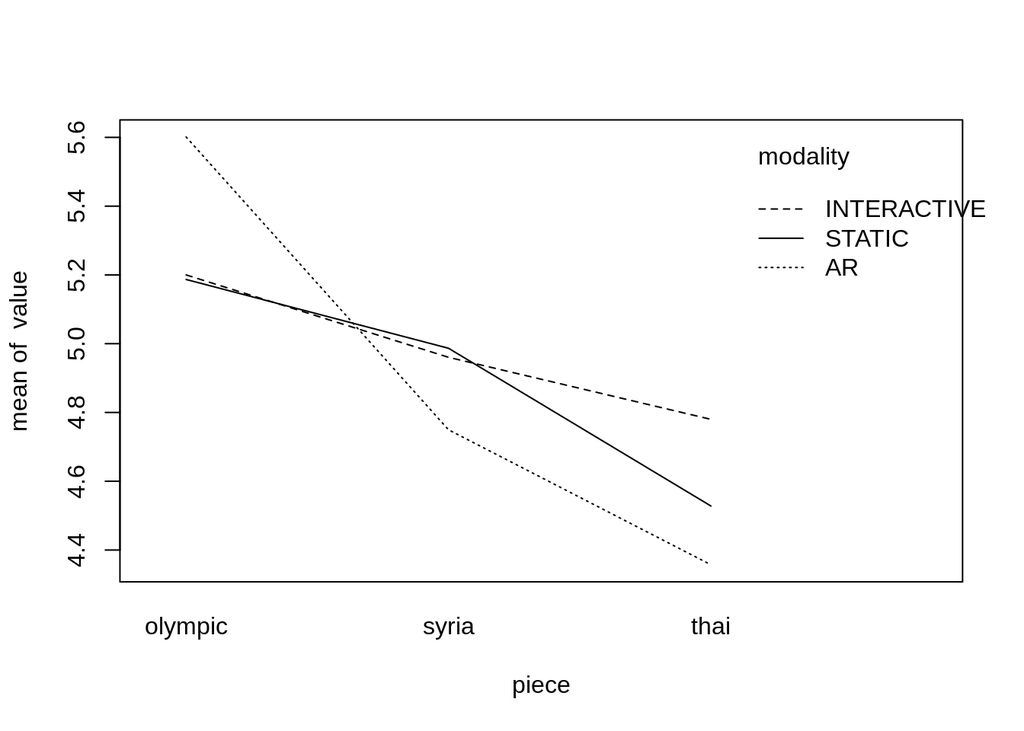

### Analysis of Variance

```r
# Define model
m = art(value ~ modality * piece + (1|subject), data=p_data)
anova(m)
```

```
## Analysis of Variance of Aligned Rank Transformed Data
##
## Table Type: Analysis of Deviance Table (Type III Wald F tests with Kenward-Roger df)
## Model: Mixed Effects (lmer)
## Response: art(value)
##
##                         F Df Df.res     Pr(>F)
## 1 modality       0.029529  2     74 0.97091460
## 2 piece          8.583362  2    148 0.00029723 ***
## 3 modality:piece 1.615882  4    148 0.17324585
## ---
## Signif. codes:   0 '***' 0.001 '**' 0.01 '*' 0.05 '.' 0.1 ' ' 1
```

*The pieces of information affect significantly the usability.*

### Post-Hoc on Piece

```r
# Pairwise comparisons using Holm-Bonferroni correction
do_post_hoc_pieces(p_data)
```

```
## Significant difference found between: thai and olympic
## --- Method=Wilcoxon rank sum test with continuity correction
## --- W=1996
## --- p-value=0.000460211155141669
##
## Significant difference found between: syria and olympic
## --- Method=Wilcoxon rank sum test with continuity correction
## --- W=2287.5
## --- p-value=0.0143307948538819
```

### Post-Hoc on Interaction

```r
# Pairwise comparisons using Holm-Bonferroni correction
do_post_hoc_modalities_pieces(p_data)
```

## Intention to adopt the technology

```r
i_cols = c('SUBJECT','CONDITION', 'WILLING_TOTAL_OLYM', 'WILLING_TOTAL_SYRIA',
           'WILLING_TOTAL_THAI')
p_data = prepare_data(df_c, i_cols)
```

```
## [1] "Subjects removed because of missing values: 0"
```

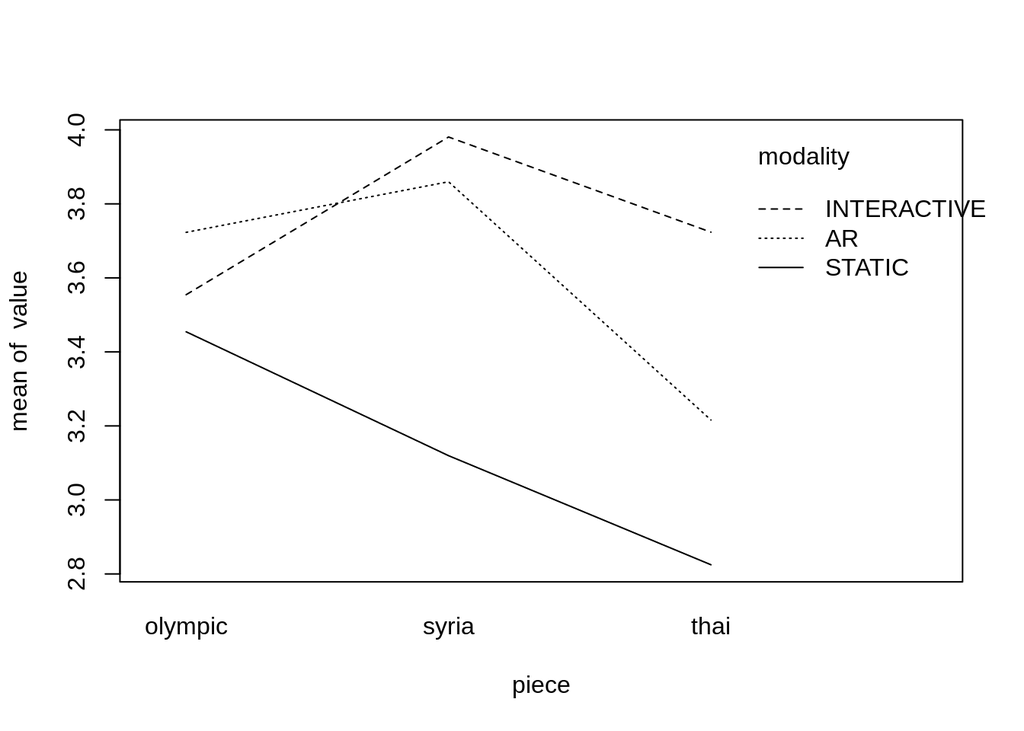

```r
# Define model
m = art(value ~ piece * modality + (1|subject), data=p_data)
anova(m)
```

```
## Analysis of Variance of Aligned Rank Transformed Data
##
## Table Type: Analysis of Deviance Table (Type III Wald F tests with Kenward-Roger df)
## Model: Mixed Effects (lmer)
## Response: art(value)
##
##                       F Df Df.res   Pr(>F)
## 1 piece          2.4106  2    152 0.093188 .
## 2 modality       1.8411  2     76 0.165646
## 3 piece:modality 1.6789  4    152 0.157723
## ---
## Signif. codes:   0 '***' 0.001 '**' 0.01 '*' 0.05 '.' 0.1 ' ' 1
```

## Engagement: Behavioral (Visuals)

```r
  i_cols = c('SUBJECT','CONDITION', 'SCREEN_TIME_VISUALS_O',
             'SCREEN_TIME_VISUALS_S', 'SCREEN_TIME_VISUALS_T')
  p_data = prepare_data(df_c, i_cols)
```

```
## [1] "Subjects removed because of missing values: 9"
```

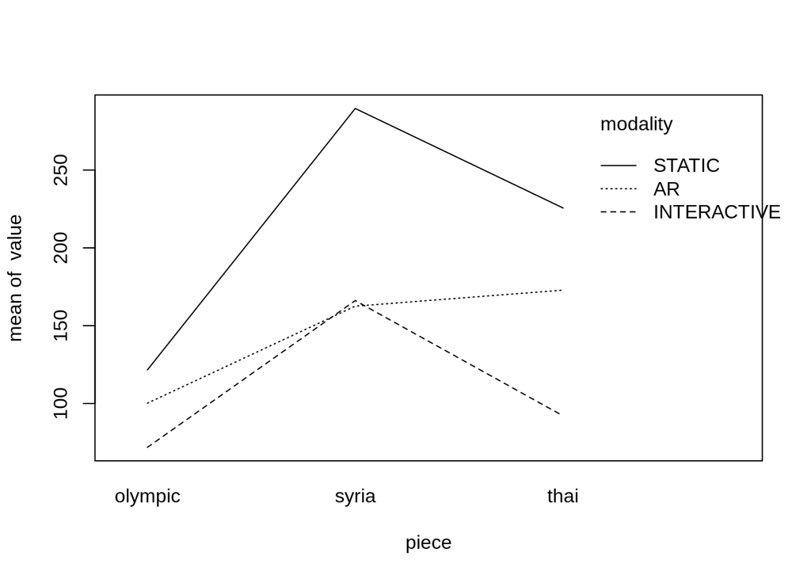

### Analysis of Variance

```r
  m = art(value ~ piece * modality + (1|subject), data=p_data)
  anova(m)
```

```
## Analysis of Variance of Aligned Rank Transformed Data
##
## Table Type: Analysis of Deviance Table (Type III Wald F tests with Kenward-Roger df)
## Model: Mixed Effects (lmer)
## Response: art(value)
##
##                        F Df Df.res     Pr(>F)
## 1 piece          121.731  2    134 < 2.22e-16 ***
## 2 modality        21.662  2     67 5.5480e-08 ***
## 3 piece:modality  18.540  4    134 3.7918e-12 ***
## ---
## Signif. codes:   0 '***' 0.001 '**' 0.01 '*' 0.05 '.' 0.1 ' ' 1
```

### Post-Hoc on Modality

```r
# Pairwise comparisons using Holm-Bonferroni correction
do_post_hoc_modalities(p_data)
```

```
## Significant difference found between: AR and INTERACTIVE
## --- Method=Wilcoxon rank sum test with continuity correction
## --- W=3577.5
## --- p-value=0.000430292179696404
##
## Significant difference found between: AR and STATIC
## --- Method=Wilcoxon rank sum test with continuity correction
## --- W=1523
## --- p-value=3.47297522082471e-05
##
## Significant difference found between: INTERACTIVE and STATIC
## --- Method=Wilcoxon rank sum test with continuity correction
## --- W=823.5
## --- p-value=3.35129160508538e-09
```

### Post-Hoc on Piece

```r
# Pairwise comparisons using Holm-Bonferroni correction
do_post_hoc_pieces(p_data)
```

```
## Significant difference found between: thai and syria
## --- Method=Wilcoxon rank sum test with continuity correction
## --- W=1939.5
## --- p-value=0.033540972219104
##
## Significant difference found between: thai and olympic
## --- Method=Wilcoxon rank sum test with continuity correction
## --- W=3687.5
## --- p-value=2.52917318455439e-07
##
## Significant difference found between: syria and olympic
## --- Method=Wilcoxon rank sum test with continuity correction
## --- W=4162.5
## --- p-value=9.66617614938646e-13
```

### Post-Hoc on Interaction

```r
# Pairwise comparisons using Holm-Bonferroni correction
do_post_hoc_modalities_pieces(p_data)
```

```
## Significant difference found between: AR and INTERACTIVE on piece thai
## --- Method=Wilcoxon rank sum test with continuity correction
## --- W=523
## --- p-value=5.80377677580655e-06
##
## Significant difference found between: AR and INTERACTIVE on piece olympic
## --- Method=Wilcoxon rank sum test with continuity correction
## --- W=426
## --- p-value=0.00978480964697434
##
## Significant difference found between: AR and STATIC on piece thai
## --- Method=Wilcoxon rank sum test with continuity correction
## --- W=180.5
## --- p-value=0.0331198788834271
##
## Significant difference found between: AR and STATIC on piece syria
## --- Method=Wilcoxon rank sum test with continuity correction
## --- W=69
## --- p-value=8.68313465907308e-06
##
## Significant difference found between: INTERACTIVE and STATIC on piece thai
## --- Method=Wilcoxon rank sum test with continuity correction
## --- W=29.5
## --- p-value=1.038786192421e-06
##
## Significant difference found between: INTERACTIVE and STATIC on piece syria
## --- Method=Wilcoxon rank sum test with continuity correction
## --- W=56.5
## --- p-value=2.35876122313537e-05
##
## Significant difference found between: INTERACTIVE and STATIC on piece olympic
## --- Method=Wilcoxon rank sum test with continuity correction
## --- W=99.5
## --- p-value=0.00145657482898621
```

*There is a significant difference in the users’ behavior between AR and Interactive on the pieces Thai and Olympic. Similarly, the difference between AR and Static is significant on the Thai and Syria pieces.*

## Engagement: Behavioral (Text)

```r
  i_cols = c('SUBJECT','CONDITION', 'SCREEN_TIME_TEXT_O',
             'SCREEN_TIME_TEXT_S', 'SCREEN_TIME_TEXT_T')
  p_data = prepare_data(df_c, i_cols)
```

```
## [1] "Subjects removed because of missing values: 9"
```

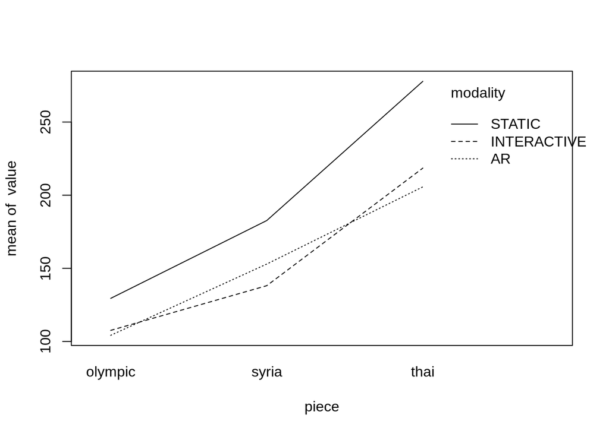

### Analysis of Variance

```r
  m = art(value ~ piece * modality + (1|subject), data=p_data)
  anova(m)
```

```
## Analysis of Variance of Aligned Rank Transformed Data
##
## Table Type: Analysis of Deviance Table (Type III Wald F tests with Kenward-Roger df)
## Model: Mixed Effects (lmer)
## Response: art(value)
##
##                         F Df Df.res   Pr(>F)
## 1 piece          194.2742  2    134  < 2e-16 ***
## 2 modality         3.7173  2     67 0.029447   *
## 3 piece:modality   2.8653  4    134 0.025695   *
## ---
## Signif. codes:   0 '***' 0.001 '**' 0.01 '*' 0.05 '.' 0.1 ' ' 1
```

### Post-Hoc on Modality

```r
# Pairwise comparisons using Holm-Bonferroni correction
do_post_hoc_modalities(p_data)
```

```
## Significant difference found between: AR and STATIC
## --- Method=Wilcoxon rank sum test with continuity correction
## --- W=1884.5
## --- p-value=0.00727140702513335
##
## Significant difference found between: INTERACTIVE and STATIC
## --- Method=Wilcoxon rank sum test with continuity correction
## --- W=1526.5
## --- p-value=0.00929548950442094
```

### Post-Hoc on Piece

```r
# Pairwise comparisons using Holm-Bonferroni correction
do_post_hoc_pieces(p_data)
```

```
## Significant difference found between: thai and syria
## --- Method=Wilcoxon rank sum test with continuity correction
## --- W=3819.5
## --- p-value=1.15896882520901e-08
##
## Significant difference found between: thai and olympic
## --- Method=Wilcoxon rank sum test with continuity correction
## --- W=4478.5
## --- p-value=2.85696116228013e-17
##
## Significant difference found between: syria and olympic
## --- Method=Wilcoxon rank sum test with continuity correction
## --- W=3615
## --- p-value=1.21273639929876e-06
```

### Post-Hoc on Interaction

```r
# Pairwise comparisons using Holm-Bonferroni correction
do_post_hoc_modalities_pieces(p_data)
```

```
## Significant difference found between: AR and STATIC on piece thai
## --- Method=Wilcoxon rank sum test with continuity correction
## --- W=164
## --- p-value=0.0133882825804612
##
## Significant difference found between: INTERACTIVE and STATIC on piece syria
## --- Method=Wilcoxon rank sum test with continuity correction
## --- W=140.5
## --- p-value=0.0287536210024665
```

*There is a significant difference in the users’ behavior between AR and Static on the Thai piece.*

## View again

```r
  i_cols = c('SUBJECT','CONDITION', 'Usabilit_Others_2_O',
             'Usabilit_Sthers_2_S', 'Usabilit_Others_2_T')
  p_data = prepare_data(df_c, i_cols)
```

```
## [1] "Subjects removed because of missing values: 0"
```

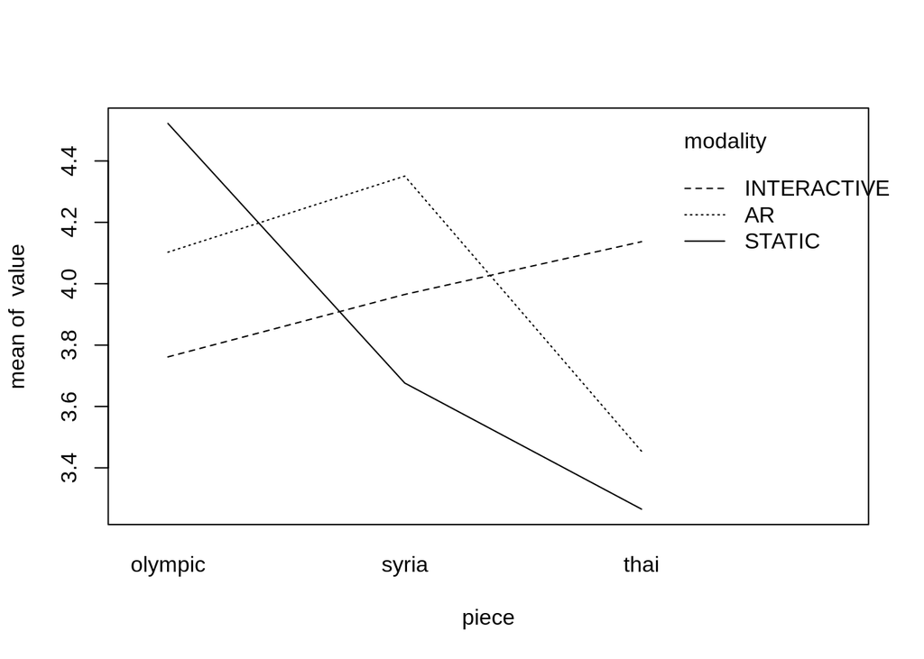

### Analysis of Variance

```r
  m = art(value ~ piece * modality + (1|subject), data=p_data)
  anova(m)
```

```
## Analysis of Variance of Aligned Rank Transformed Data
##
## Table Type: Analysis of Deviance Table (Type III Wald F tests with Kenward-Roger df)
## Model: Mixed Effects (lmer)
## Response: art(value)
##
##                        F Df Df.res   Pr(>F)
## 1 piece          2.98990  2    152 0.053259 .
## 2 modality       0.07082  2     76 0.931691
## 3 piece:modality 3.33190  4    152 0.011988 *
## ---
## Signif. codes:   0 '***' 0.001 '**' 0.01 '*' 0.05 '.' 0.1 ' ' 1
```

### Post-Hoc on Interaction

```r
# Pairwise comparisons using Holm-Bonferroni correction
do_post_hoc_modalities_pieces(p_data)
```

## Interest

```r
  i_cols = c('SUBJECT','CONDITION', 'Usabilit_Others_1_O',
             'Usabilit_Sthers_1_S', 'Usabilit_Others_1_T')
  p_data = prepare_data(df_c, i_cols)
```

```
## [1] "Subjects removed because of missing values: 0"
```

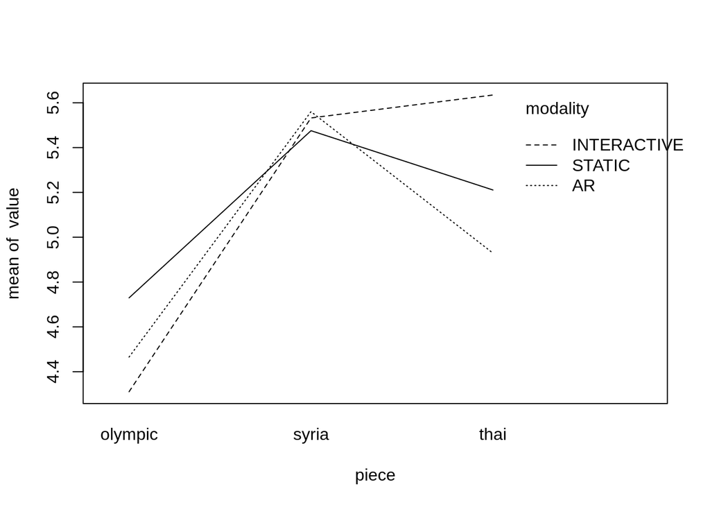

### Analysis of Variance

```r
  m = art(value ~ piece * modality + (1|subject), data=p_data)
  anova(m)
```

```
## Analysis of Variance of Aligned Rank Transformed Data
##
## Table Type: Analysis of Deviance Table (Type III Wald F tests with Kenward-Roger df)
## Model: Mixed Effects (lmer)
## Response: art(value)
##
##                        F Df Df.res     Pr(>F)
## 1 piece          17.7141  2    152 1.2152e-07 ***
## 2 modality        0.5538  2     76    0.57706
## 3 piece:modality  1.4203  4    152    0.22989
## ---
## Signif. codes:   0 '***' 0.001 '**' 0.01 '*' 0.05 '.' 0.1 ' ' 1
```

### Post-Hoc on Piece

```r
# Pairwise comparisons using Holm-Bonferroni correction
do_post_hoc_pieces(p_data)
```

```
## Significant difference found between: thai and olympic
## --- Method=Wilcoxon rank sum test with continuity correction
## --- W=4119
## --- p-value=0.000518523462284851
##
## Significant difference found between: syria and olympic
## --- Method=Wilcoxon rank sum test with continuity correction
## --- W=4508.5
## --- p-value=1.38742393577081e-06
```

## Comfortable

```r
  i_cols = c('SUBJECT','CONDITION', 'Usabilit_Others_3_O',
             'Usabilit_Sthers_3_S', 'Usabilit_Others_3_T')
  p_data = prepare_data(df_c, i_cols)
```

```
## [1] "Subjects removed because of missing values: 0"
```

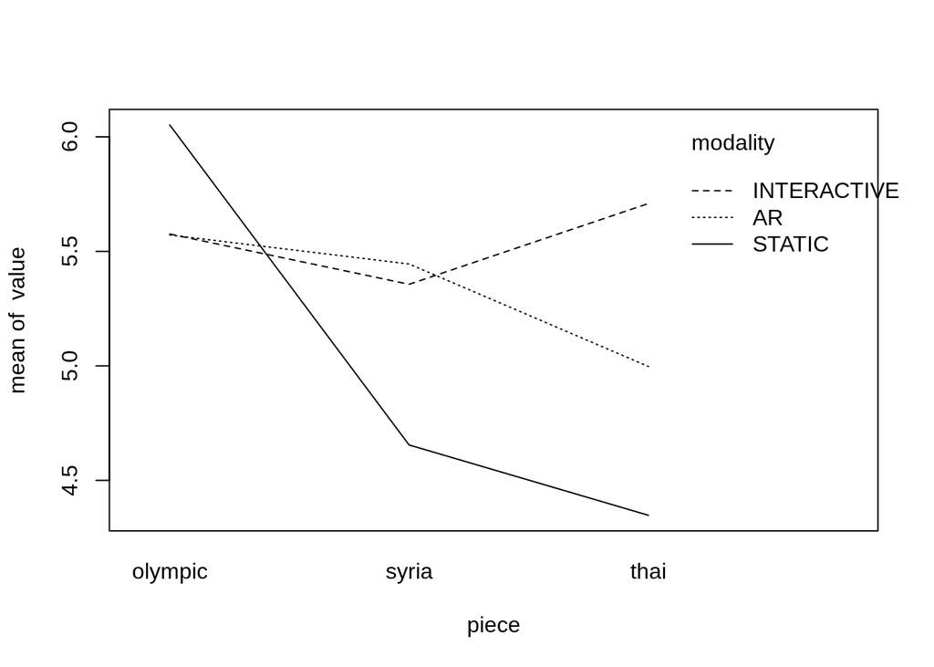

### Analysis of Variance

```r
  m = art(value ~ piece * modality + (1|subject), data=p_data)
  anova(m)
```

```
## Analysis of Variance of Aligned Rank Transformed Data
##
## Table Type: Analysis of Deviance Table (Type III Wald F tests with Kenward-Roger df)
## Model: Mixed Effects (lmer)
## Response: art(value)
##
##                        F Df Df.res     Pr(>F)
## 1 piece          11.4027  2    152 2.4320e-05 ***
## 2 modality        2.6295  2     76   0.078669   .
## 3 piece:modality  7.0851  4    152 2.9451e-05 ***
## ---
## Signif. codes:   0 '***' 0.001 '**' 0.01 '*' 0.05 '.' 0.1 ' ' 1
```

### Post-Hoc on Piece

```r
# Pairwise comparisons using Holm-Bonferroni correction
do_post_hoc_pieces(p_data)
```

```
## Significant difference found between: thai and olympic
## --- Method=Wilcoxon rank sum test with continuity correction
## --- W=2249.5
## --- p-value=0.00241953448276065
##
## Significant difference found between: syria and olympic
## --- Method=Wilcoxon rank sum test with continuity correction
## --- W=2318
## --- p-value=0.00519761598643239
```

### Post-Hoc on Interaction

```r
# Pairwise comparisons using Holm-Bonferroni correction
do_post_hoc_modalities_pieces(p_data)
```

```
## Significant difference found between: AR and INTERACTIVE on piece thai
## --- Method=Wilcoxon rank sum test with continuity correction
## --- W=242
## --- p-value=0.0232121058359594
##
## Significant difference found between: AR and STATIC on piece syria
## --- Method=Wilcoxon rank sum test with continuity correction
## --- W=466.5
## --- p-value=0.0349667667824976
##
## Significant difference found between: INTERACTIVE and STATIC on piece thai
## --- Method=Wilcoxon rank sum test with continuity correction
## --- W=469
## --- p-value=0.00234004942030025
```

## Specific Learning Modified Analysis

```r
  i_cols = c('SUBJECT','CONDITION', 'OBJECT_LEARN_SPEC_ALL_O',
             'OBJECTLEARN_TOTAL_S_ONLY4ITEMS', 'OBJECTLEARN_TOTAL_T_ONLY2ITEMS')

  p_data = prepare_data(filter(df_c, filter_. != 0), i_cols)
```

```
## [1] "Subjects removed because of missing values: 36"
```

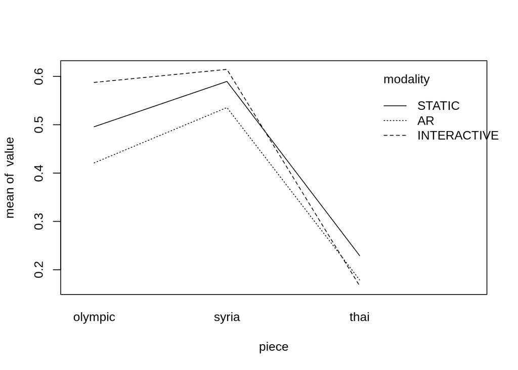

### Analysis of Variance

```r
  m = art(value ~ piece * modality + (1|subject), data=p_data)
  anova(m)
```

```
## Analysis of Variance of Aligned Rank Transformed Data
##
## Table Type: Analysis of Deviance Table (Type III Wald F tests with Kenward-Roger df)
## Model: Mixed Effects (lmer)
## Response: art(value)
##
##                         F Df Df.res     Pr(>F)
## 1 piece          39.67336  2     80 1.0712e-12 ***
## 2 modality        0.95680  2     40    0.39273
## 3 piece:modality  0.69558  4     80    0.59721
## ---
## Signif. codes:   0 '***' 0.001 '**' 0.01 '*' 0.05 '.' 0.1 ' ' 1
```

### Post-Hoc on Piece

```r
# Pairwise comparisons using Holm-Bonferroni correction
do_post_hoc_pieces(p_data)
```

```
## Significant difference found between: thai and syria
## --- Method=Wilcoxon rank sum test with continuity correction
## --- W=235
## --- p-value=1.67883090069624e-09
##
## Significant difference found between: thai and olympic
## --- Method=Wilcoxon rank sum test with continuity correction
## --- W=339
## --- p-value=2.77219453971305e-07
```

## Summary

Summary of significant difference between factors. * indicates significant difference

[output not shown]

Summary of significant differences on pairwise comparison between modalities. * indicates significant difference

[output not shown]